# v19notes

Jeff

9 mai 2016

## Week 19, 2016

This is week 10 of of the internship!

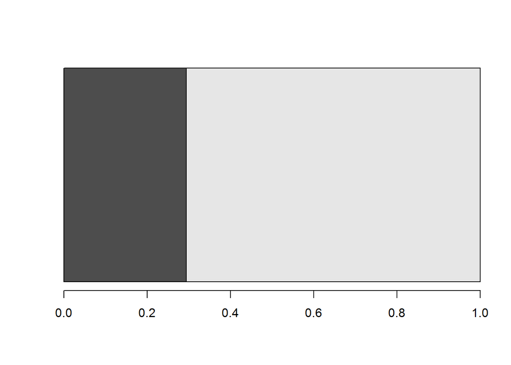

```r
thisweek <- 10
yikes <- c(thisweek, 34-thisweek) / 34
barplot(as.matrix(yikes), horiz=TRUE, beside=FALSE)
```

Last week I got all our current scores loaded into a local postgres database; poked through a shiny tutorial; switched from RPostgres driver to dplyr (for better or worse); and corrected a first CRPS plot to make a little sense.

It’s true, sometimes this geologist struggles to grok the model scores in forecasting!

This week I need to:

- decide if the SOS database format is the way to go forward,
  - which makes maintenance easier
  - but dplyr less useful
  - and I’d learn curl
- load data to AWS instance
  - use .Renviron to point at dev / prod databases
- mysteries to solve
  - where does dplyr disconnect pooled connections?
  - strategies for a multi-user app?
- R fundamentals I still need
  - difference btw filter() and subset?
  - ggplot2
  - facet()

We need a structure for the scores to import - currently receiving text files and 3D “cubes” depending on source… tidying takes time; should be automated so users may load / arrange their scores (EVS)

Working with “reactive” call today: https://gallery.shinyapps.io/003-reactivity/

Confidence Intervals discussed in different context: http://learnbayes.org/papers/confidenceIntervalsFallacy/introduction.html …with nifty Shiny app to illustrate Figs 1 - 5 from article: https://richarddmorey.shinyapps.io/confidenceFallacy/ http://learnbayes.org/papers/confidenceIntervalsFallacy/